# Part II - Loan Data from Prosper

## by Fabi Daniel

## Investigation Overview

> The *task* is to accurately determine the *factors* that affect the *Loan Outcome status* and to give an answer to the *Question* how *well* are the Prosper Loans Doing? Special Focus was put on some variables based on the assumption that the **Rates**, **Principal** and **Term** are important in any loan Situation.

To clarify, the loan status was categorized

- `Positive Loan Status`: This basically is for Loans that are healthy i.e currently running, loans in their final stages and loans already completed
- `Negative Loan Status`: This is for Loans that are unhealthy i.e Cancelled, Chargedoff and Past Due

## Dataset Overview

This data set contains 113,937 loans with 81 variables on each loan, including loan amount, borrower rate (or interest rate), current loan status, term, borrower income, and many others. The dataset was later trimmed to 12 columns removing columns that are surplus to our investigation and deleting rows with Null Values. Special Focus was put on some variables based on the assumption that the **Rates**, **Principal** and **Term** are important in any loan situation.

## Visualization 1

What is the ratio of Positive loan Status?

- Current and Completed that are elements in my assumed **Positive Loan Status** are the most occuring Loan Status.

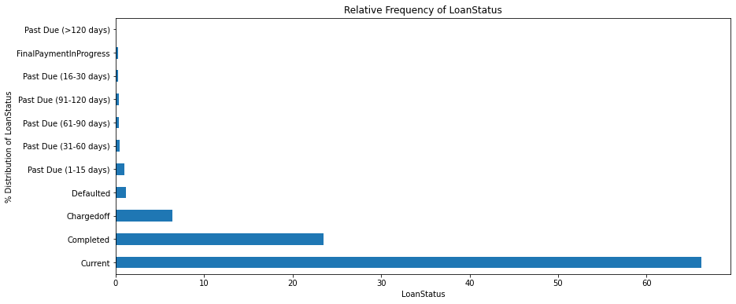

Fig 1: Relative Frequency of Loan Status

## Visualization 2

Does **loan status** have anything to do **BorrowerRate?**

- Does the **BorrowerRate** have an influence on the completion status of the Loan?
  > - Quite Evident, Past Due(>120 days) has the highest minimum rate, while the lowest minimum is in the Completed Status followed by the current status

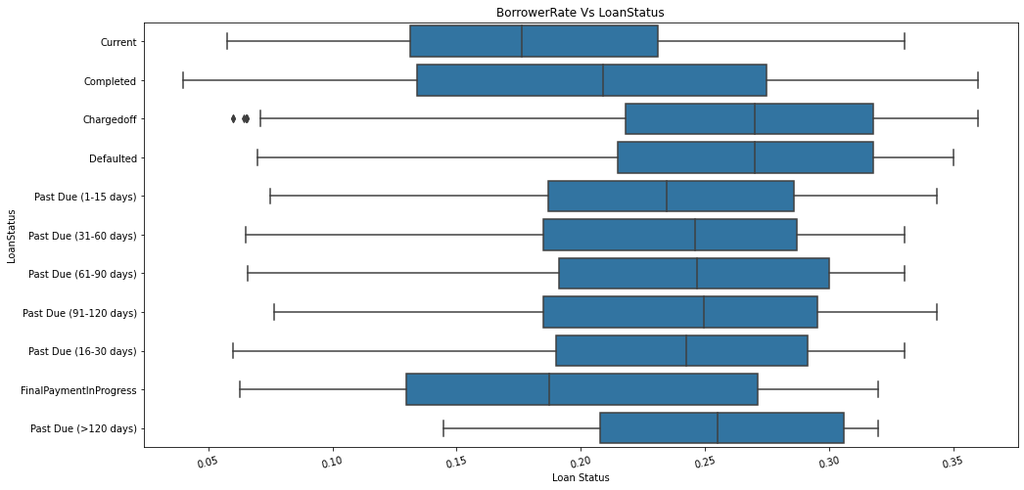

Fig 2: Bivariate Visualization of LoanStatus Vs BorrowerRate

## Visualization 3

What Term and ProsperRating influences Loan Status?

- Across all Loan terms, the Frequency and Order of the Loan Status have always been consistent *(Current & Completed respectively)* with only the exception of 12 months loans, having more completed than current.
- Prosper Rating D is the most completed while ProsperRating C is the most occuring

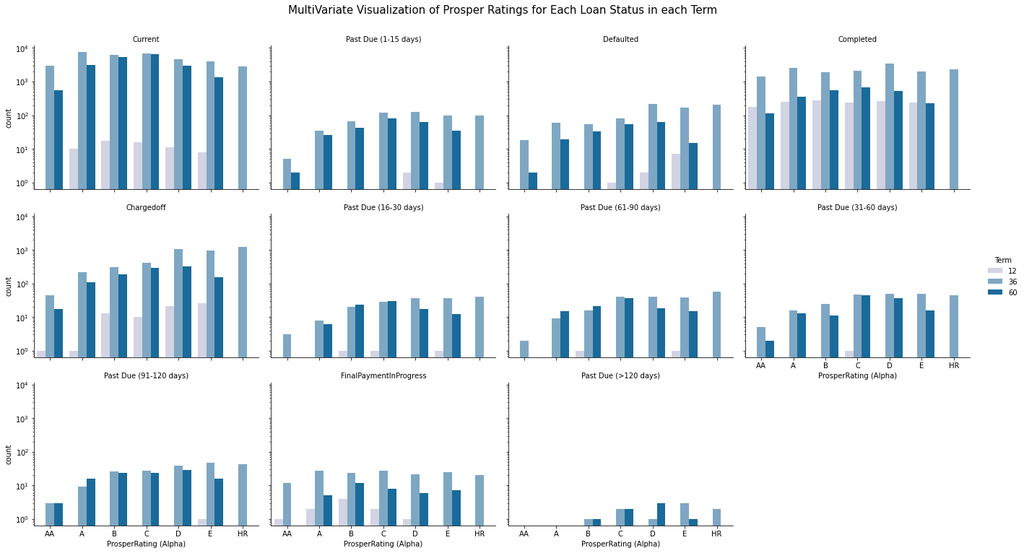

Fig 2: MultiVariate Visualization of Prosper Ratings for Each Loan Status in each Term

## Key Insights for Presentation

Across all terms the Frequency and Order of the Loan Status have always been consistent with only the exception of 12 months loans, having more completed than current.